# Lesly M. Sierra Fontalvo

Ingeniera mecánica

## Acerca de mi

Soy ingeniera mecánica y actualmente profesora catedrática en el departamento de ingeniería mecánica, Universidad del Norte, Barranquilla. Mis intereses de investigación incluyen obsolescencia, diseño de productos circulares y metodologías de diseño para X.

Estoy estudiando una maestría en ingeniería mecánica relacionada con pronosticar el riesgo de obsolescencia de un producto a partir de sus atributos de diseño. He realizado investigaciones sobre obsolescencia, métricas de circularidad de productos de base biológica y eficiencia energética en camiones mineros.

## Experiencia laboral

#### Docente catedrática.

- Profesora de laboratorio en la asignatura ciencia de los materiales  
  Universidad del norte, Puerto Colombia, Atlántico, Colombia.  
  Enero 2024 - Actual
- Profesora de laboratorio en la asignatura procesos de fabricación  
  Universidad del norte, Puerto Colombia, Atlántico, Colombia  
  Julio 2023 - Noviembre 2023.

#### Asistente de investigación

- Proyecto: Evaluación del potencial bioeconómico y de circularidad del bioaceite y el biochar a partir de la pirólisis rápida de la biomasa  
  Universidad del norte, Puerto Colombia, Atlántico, Colombia.  
  Junio 2023 - Enero 2024
- Proyecto: Diseño de un modelo para el diagnóstico de la obsolescencia de productos  
  Universidad del norte, Puerto Colombia, Atlántico, Colombia.  
  Diciembre 2022 - Diciembre 2023

#### Ingeniera de proyectos

Resumen: Coordinadora técnica en el proyecto denominado “evaluación de alternativas para el accionamiento bajo en carbono de la flota de camiones mineros en Cerro Matoso: diésel/hidrógeno, gas natural e hibrido (fase I)”.  
Universidad del norte, Puerto Colombia, Atlántico, Colombia.  
Octubre 2022 – Abril 2023.

## Publicaciones

1. **Sierra-Fontalvo, L.**, Polo-Cardozo, J., Maury-Ramírez, H., & Mesa, J. A. (2024). Diagnosing remanufacture potential at product-component level: A disassemblability and integrity approach. Resources, Conservation and Recycling, 205, 107529. https://doi.org/10.1016/j.resconrec.2024.107529
2. Mesa, J. A., **Sierra-Fontalvo, L.**, Ortegon, K., & Gonzalez-Quiroga, A. (2024). Advancing circular bioeconomy: A critical review and assessment of indicators. Sustainable Production and Consumption, 46, 324-342. https://doi.org/10.1016/j.spc.2024.03.006
3. **Sierra-Fontalvo, L.**, Gonzalez-Quiroga, A., & Mesa, J. A. (2023). A deep dive into addressing obsolescence in product design: A review. Heliyon, 9(11), e21856. https://doi.org/10.1016/j.heliyon.2023.e21856

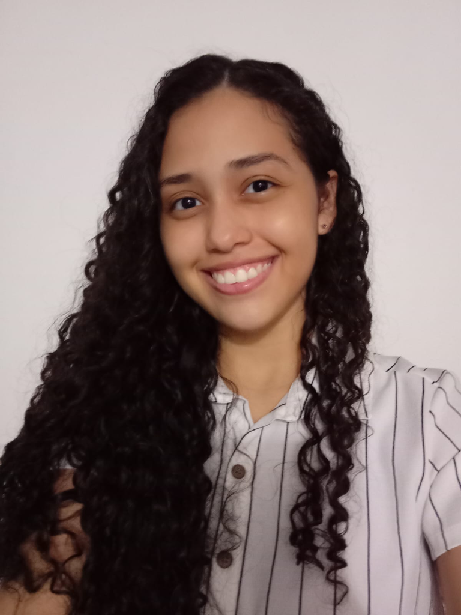